# RECOMENDATION SYSTEM

```python
import numpy as np
import pandas as pd
import seaborn as sns
import matplotlib.pyplot as plt
%matplotlib inline
from sklearn import preprocessing
from collections import defaultdict
from surprise import SVD
from surprise import KNNWithMeans
from surprise import Dataset
from surprise import accuracy
from surprise import Reader
from surprise.model_selection import cross_validate
from surprise.model_selection import train_test_split

# Suppressing Warnings
import warnings
warnings.filterwarnings('ignore')
#Loading Data files
```

```python
df1 = pd.read_csv('downloads/phone_user_review_file_1.csv')
```

```python
df2 = pd.read_csv('downloads/phone_user_review_file_2.csv')
```

```python
df3 = pd.read_csv('downloads/phone_user_review_file_3.csv')
```

```python
df4 = pd.read_csv('downloads/phone_user_review_file_4.csv')
```

```python
df5 = pd.read_csv('downloads/phone_user_review_file_5.csv')
```

```python
df6 = pd.read_csv('downloads/phone_user_review_file_6.csv')
```

```python
df = pd.concat([df1,df2,df3,df4,df5,df6]).drop_duplicates()
```

```python
df.head()
```

|  | phone_url | date | lang | country | source | domain | score | score_max | extract | author | product |
| --- | --- | --- | --- | --- | --- | --- | --- | --- | --- | --- | --- |
| 0 | /cellphones/samsung-galaxy-s8/ | 5/2/2017 | en | us | Verizon Wireless | verizonwireless.com | 10.0 | 10.0 | As a diehard Samsung fan who has had every Sam... | CarolAnn35 | Samsung Galaxy S8 |
| 1 | /cellphones/samsung-galaxy-s8/ | 4/28/2017 | en | us | Phone Arena | phonearena.com | 10.0 | 10.0 | Love the phone. the phone is sleek and smooth ... | james0923 | Samsung Galaxy S8 |
| 2 | /cellphones/samsung-galaxy-s8/ | 5/4/2017 | en | us | Amazon | amazon.com | 6.0 | 10.0 | Adequate feel. Nice heft. Processor's still sl... | R. Craig | Samsung Galaxy S8 (64GB) G950U 5.8" 4G LTE Unl... |
| 3 | /cellphones/samsung-galaxy-s8/ | 5/2/2017 | en | us | Samsung | samsung.com | 9.2 | 10.0 | Never disappointed. One of the reasons I've be... | Buster2020 | Samsung Galaxy S8 64GB (AT&T) |
| 4 | /cellphones/samsung-galaxy-s8/ | 5/11/2017 | en | us | Verizon Wireless | verizonwireless.com | 4.0 | 10.0 | I've now found that i'm in a group of people t... | S Ate Mine | Samsung Galaxy S8 |

```python
df.info()
```

```
<class 'pandas.core.frame.DataFrame'>
Int64Index: 1408721 entries, 0 to 163836
Data columns (total 11 columns):
 #   Column     Non-Null Count    Dtype
---  ------     --------------    -----
 0   phone_url  1408721 non-null  object
 1   date       1408721 non-null  object
 2   lang       1408721 non-null  object
 3   country    1408721 non-null  object
 4   source     1408721 non-null  object
 5   domain     1408721 non-null  object
 6   score      1345628 non-null  float64
 7   score_max  1345628 non-null  float64
 8   extract    1389707 non-null  object
 9   author     1346904 non-null  object
 10  product    1408720 non-null  object
dtypes: float64(2), object(9)
memory usage: 129.0+ MB
```

```python
df.shape
```

```
(1408721, 11)
```

```python
df_copy=df.copy()
```

```python
df_copy.describe()
```

|  | score | score_max |
| --- | --- | --- |
| count | 1.345628e+06 | 1345628.0 |
| mean | 8.006265e+00 | 10.0 |
| std | 2.616463e+00 | 0.0 |
| min | 2.000000e-01 | 10.0 |
| 25% | 7.200000e+00 | 10.0 |
| 50% | 9.200000e+00 | 10.0 |
| 75% | 1.000000e+01 | 10.0 |
| max | 1.000000e+01 | 10.0 |

```python
df_copy.isnull().values.any()
```

```
True
```

```python
N=df_copy.isnull().sum()
```

```python
print(N)
```

```
phone_url        0
date             0
lang             0
country          0
source           0
domain           0
score        63093
score_max    63093
extract      19014
author       61817
product          1
dtype: int64
```

```python
df_copy= df_copy.fillna(df_copy.median())
```

```python
df_copy = df_copy.dropna()
```

```python
df_copy['score'] = df_copy['score'].astype(int)
df_copy['score_max'] = df_copy['score_max'].astype(int)
```

```python
df_copy.shape
```

```
(1331607, 11)
```

```python
dup = df_copy.drop_duplicates()
```

```python
dup.drop(['phone_url','date','lang','country','source','domain','score_max','extract'], axis = 1, inplace = True)
```

```python
ori = dup.copy()
```

```python
ori.shape
```

```
(1331600, 3)
```

```python
fin=ori.sample(n=1000000, random_state=612)
```

```python
fin.groupby('product')['score'].mean().sort_values(ascending=False).head()
```

```
product
Smartphone Sony Xperia E1 Desbloqueado Vivo Android 4.3 Tela 4 4GB 3G Wi-Fi Câmera 3MP - Branco                    10.0
Samsung Smartphone Samsung Galaxy S5 Desbloqueado Branco Android 4.4.2 4G Câmera 16 MP Memória Interna 16 GB       10.0
Samsung Smartphone Samsung Galaxy S5 Duos Desbloqueado/ Dual Chip / Branco / 4G / 16 MP / Android 4.4              10.0
Samsung Smartphone Samsung Galaxy S5 Desbloqueado/ Branco / 4G / 16 MP / Android 4.4.2 / 16 GB / USB 3.0           10.0
Samsung Smartphone Samsung Galaxy S5 Desbloqueado Vivo Preto Android 4.4.2 4G Câmera 16 MP Memória Interna 16GB    10.0
Name: score, dtype: float64
```

```python
(fin['author'].value_counts()).head()
```

```
Amazon Customer    57765
Cliente Amazon     14564
e-bit               6309
Client d'Amazon     5720
Amazon Kunde        3624
Name: author, dtype: int64
```

```python
fin['product'].value_counts().head()
```

```
Lenovo Vibe K4 Note (White,16GB)     3908
Lenovo Vibe K4 Note (Black, 16GB)    3234
OnePlus 3 (Graphite, 64 GB)          3128
OnePlus 3 (Soft Gold, 64 GB)         2643
Huawei P8lite zwart / 16 GB          1994
Name: product, dtype: int64
```

```python
fin1 = pd.DataFrame(columns=['author', 'a_count'])
fin1['author']=fin['author'].value_counts().index.tolist()
fin1['a_count'] = list(fin['author'].value_counts() > 50)
```

```python
index = fin1[ fin1['a_count'] == False ].index
# drop these row indexes from dataFrame
fin1.drop(index, inplace = True)
fin1
```

|  | author | a_count |
| --- | --- | --- |
| 0 | Amazon Customer | True |
| 1 | Cliente Amazon | True |
| 2 | e-bit | True |
| 3 | Client d'Amazon | True |
| 4 | Amazon Kunde | True |
| ... | ... | ... |
| 674 | Ralf | True |
| 675 | ugurcam | True |
| 676 | Carla | True |
| 677 | Ann | True |
| 678 | Jens | True |

679 rows × 2 columns

```python
# extracting product that got more than 50 ratings
f2 = pd.DataFrame(columns=['product', 'p_count'])
f2['product']=fin['product'].value_counts().index.tolist()
f2['p_count'] = list(fin['product'].value_counts() > 50)
```

```python
index = f2[ f2['p_count'] == False ].index
# drop these row indexes from dataFrame
f2.drop(index, inplace = True)
```

```python
f2
```

|  | product | p_count |
| --- | --- | --- |
| 0 | Lenovo Vibe K4 Note (White,16GB) | True |
| 1 | Lenovo Vibe K4 Note (Black, 16GB) | True |
| 2 | OnePlus 3 (Graphite, 64 GB) | True |
| 3 | OnePlus 3 (Soft Gold, 64 GB) | True |
| 4 | Huawei P8lite zwart / 16 GB | True |
| ... | ... | ... |
| 4341 | Tracfone LG 306G with 600 Minutes and Triple M... | True |
| 4342 | Nokia Lumia 720 Sim Free Windows Smartphone - ... | True |
| 4343 | LG KC910 Renoir | True |
| 4344 | Samsung Galaxy S4, Red Aurora 16GB (AT&T) | True |
| 4345 | Sony Ericsson Xperia pro Smartphone (9.4 cm (3... | True |

4346 rows × 2 columns

```python
f3 = fin[fin['product'].isin(f2['product'])]
f3
```

|  | score | author | product |
| --- | --- | --- | --- |
| 104246 | 10 | Paul B | Samsung i897 Captivate Android Smartphone Gala... |
| 78693 | 10 | Yuvraj | Blu Win JR LTE (Grey, 4GB) |
| 8816 | 2 | Joyce D. Pratt | BLU Vivo XL Smartphone - 5.5" 4G LTE - GSM Unl... |
| 116623 | 10 | David B | Samsung S3350 Chat 335 Sim Free Mobile Phone |
| 35333 | 10 | Sebastian | Samsung E1190 Handy (3,6 cm (1,43 Zoll) Displa... |
| ... | ... | ... | ... |
| 87173 | 8 | Javier | Huawei Ascend Y330 - Smartphone libre Android ... |
| 281625 | 8 | Patrix | Huawei Ascend G510 Smartphone Touch, Fotocamer... |
| 110881 | 2 | Amazon Customer | Apple iPhone 5C Factory Unlocked Cellphone, 8G... |
| 36197 | 10 | majere1975 | Samsung Smartphone Galaxy S Advance, Display 4... |
| 99081 | 10 | ALBERT M. MASSILLON | BLU Dash JR K Smartphone - Unlocked - Black |

558101 rows × 3 columns

Q2 C - Select the data with products having more than 50 ratings and users who have given more than 50 ratings. Report the shape of the final dataset.

```python
f4 = f3[f3['author'].isin(fin1['author'])]
f4
```

|  | score | author | product |
| --- | --- | --- | --- |
| 35333 | 10 | Sebastian | Samsung E1190 Handy (3,6 cm (1,43 Zoll) Displa... |
| 290678 | 8 | sara | Samsung SM-N910F Galaxy Note 4 Smartphone, 32 ... |
| 101404 | 10 | Евгений | Sony Xperia Z1 Compact (лайм) |
| 223332 | 8 | Amazon Customer | Motorola Moto G 3rd Generation SIM-Free Smartp... |
| 361379 | 10 | e-bit | Smartphone Motorola Moto G 4 Play XT1603 |
| ... | ... | ... | ... |
| 21110 | 2 | Amazon customer | Tracfone Motorola Moto E Android Prepaid Phone... |
| 321740 | 8 | Qantas | Sony Ericsson K810i Cyber-shot |
| 269553 | 9 | Capyto | Samsung M150 Cep Telefonu |
| 87173 | 8 | Javier | Huawei Ascend Y330 - Smartphone libre Android ... |
| 110881 | 2 | Amazon Customer | Apple iPhone 5C Factory Unlocked Cellphone, 8G... |

108983 rows × 3 columns

Shape of data

```python
f4.shape
```

```
(108983, 3)
```

Q3 - Build a popularity based model and recommend top 5 mobile phones.

```python
mean = pd.DataFrame(fin.groupby('product')['score'].mean())
```

```python
mean['rating_counts'] = pd.DataFrame(fin.groupby('product')['score'].count())
```

```python
mean.sort_values(by=['score','rating_counts'], ascending=[False,False]).head(5)
```

| product | score | rating_counts |
| --- | --- | --- |
| Samsung Galaxy Note5 | 10.0 | 144 |
| Nokia Smartphone Nokia Lumia 520 Desbloqueado Oi Preto Windows Phone 8 Câmera 5MP 3G Wi-Fi Memória Interna 8G GPS | 10.0 | 132 |
| Motorola Smartphone Motorola Moto X Desbloqueado Preto Android 4.2.2 Câmera 10MP e Frontal 2MP Memória Interna de 16GB GSM | 10.0 | 131 |
| Samsung Smartphone Galaxy Win Duos Branco Desbloqueado Dual Chip Câmera 5MP Processador Quad Core 1.2 Ghz Android 4.1 3G Wi- Fi e Memória 8GB | 10.0 | 127 |
| Motorola Smartphone Motorola Moto G Dual Chip Desbloqueado TIM Android 4.3 Tela 4.5 8GB 3G Wi-Fi Câmera 5MP - Preto | 10.0 | 126 |

```python
data = fin
fin
```

|  | score | author | product |
| --- | --- | --- | --- |
| 104246 | 10 | Paul B | Samsung i897 Captivate Android Smartphone Gala... |
| 78693 | 10 | Yuvraj | Blu Win JR LTE (Grey, 4GB) |
| 109329 | 10 | Pankaj Bhalla | Lenovo P780 (Deep Black, 4GB) |
| 64164 | 6 | Bgrazina | Samsung Galaxy XCover 2 |
| 8816 | 2 | Joyce D. Pratt | BLU Vivo XL Smartphone - 5.5" 4G LTE - GSM Unl... |
| ... | ... | ... | ... |
| 70406 | 4 | Dudls | Nokia 301 Dual |
| 16189 | 8 | Cintaaa__ | LG Viewty KU990 |
| 99081 | 10 | ALBERT M. MASSILLON | BLU Dash JR K Smartphone - Unlocked - Black |
| 102484 | 2 | Amazon Customer | Samsung Galaxy S6 SM-G920F 32GB (FACTORY UNLOC... |
| 7271 | 2 | Amazon Customer | Sony Xperia Z3 D6653 16GB (FACTORY UNLOCKED) G... |

1000000 rows × 3 columns

Build a collaborative filtering model using SVD.

```python
columns_titles = ['author','product','score']
data1 = ori.reindex(columns=columns_titles)
```

```python
samp_data = data1.sample(n=5000, random_state=612)
```

```python
reader = Reader(rating_scale=(1, 10))
data2= Dataset.load_from_df(samp_data,reader = reader)
```

```python
trainset = data2.build_full_trainset()
trainset.ur
```

[output not shown]

[output cut: 1391 more lines]

[output not shown]

```python
algo = SVD()
algo.fit(trainset)
```

```
<surprise.prediction_algorithms.matrix_factorization.SVD at 0x2cb831906d0>
```

```python
testset = trainset.build_anti_testset()
```

```python
predictions = algo.test(testset)
```

```python
predictions
```

[output not shown]

[output cut: 975 more lines]

```python
def get_top_n(predictions, n=5):
    # First map the predictions to each user.
    top_n = defaultdict(list)
    for uid, iid, true_r, est, _ in predictions:
        top_n[uid].append((iid, est))

    # Then sort the predictions for each user and retrieve the k highest ones.
    for uid, user_ratings in top_n.items():
        user_ratings.sort(key=lambda x: x[1], reverse=True)
        top_n[uid] = user_ratings[:n]

    return top_n
```

```python
top_n = get_top_n(predictions, n=5)
top_n
```

[output not shown]

[output cut: 8660 more lines]

[output not shown]

Evaluate the collaborative model. Print RMSE value for SVD

```python
print("SVD Model : Test Set")
accuracy.rmse(predictions, verbose=True)
```

```
SVD Model : Test Set
RMSE: 0.3372
```

```
0.3371653412390458
```

```python
def get_Iu(uid):
    """ return the number of items rated by given user
    args:
      uid: the id of the user
    returns:
      the number of items rated by the user
    """
    try:
        return len(trainset.ur[trainset.to_inner_uid(uid)])
    except ValueError: # user was not part of the trainset
        return 0

def get_Ui(iid):
    """ return number of users that have rated given item
    args:
      iid: the raw id of the item
    returns:
      the number of users that have rated the item.
      """
    try:
        return len(trainset.ir[trainset.to_inner_iid(iid)])
    except ValueError:
        return 0

bf = pd.DataFrame(predictions, columns=['uid', 'iid', 'rui', 'est', 'details'])
bf['Iu'] = bf.uid.apply(get_Iu)
bf['Ui'] = bf.iid.apply(get_Ui)
bf['err'] = abs(bf.est - bf.rui)
best_predictions = bf.sort_values(by='err')[:10]
worst_predictions = bf.sort_values(by='err')[-10:]
```

```python
best_predictions
```

|  | uid | iid | rui | est | details | Iu | Ui | err |
| --- | --- | --- | --- | --- | --- | --- | --- | --- |
| 2502894 | ALE.V. | Sony Ericsson Vivaz U5i | 8.0086 | 8.0086 | {'was_impossible': False} | 1 | 1 | 4.404741e-08 |
| 15624051 | Stuff | Samsung Verizon Samsung Convoy U660 No Contrac... | 8.0086 | 8.0086 | {'was_impossible': False} | 1 | 3 | 9.247787e-08 |
| 3617510 | Giliander | Microsoft Lumia 540 (Black) | 8.0086 | 8.0086 | {'was_impossible': False} | 1 | 1 | 1.161084e-07 |
| 12837299 | Ozel | BLU VIVO 5R Refresh Smartphone - 5.5-Inch Disp... | 8.0086 | 8.0086 | {'was_impossible': False} | 1 | 1 | 1.361107e-07 |
| 6892313 | NT1975 | Samsung E1270 Telefono Cellulare | 8.0086 | 8.0086 | {'was_impossible': False} | 1 | 1 | 1.586271e-07 |
| 7804371 | RG-GONZA | Sony Xperia Z | 8.0086 | 8.0086 | {'was_impossible': False} | 1 | 1 | 2.680444e-07 |
| 15647056 | SimonElgers | Samsung Galaxy Nexus \| Black | 8.0086 | 8.0086 | {'was_impossible': False} | 1 | 2 | 2.687853e-07 |
| 15178245 | Naschkatzl | [Official Store] DOOGEE X5 Max Pro Smartphone,... | 8.0086 | 8.0086 | {'was_impossible': False} | 1 | 1 | 2.801065e-07 |
| 5563545 | Giorgio | Elephone Batería Original para Elephone P7000 | 8.0086 | 8.0086 | {'was_impossible': False} | 1 | 1 | 2.842895e-07 |
| 1078044 | Samantha dicker | Samsung Galaxy S6 edge+ 64GB (AT&T) | 8.0086 | 8.0086 | {'was_impossible': False} | 1 | 2 | 3.231010e-07 |

Build a collaborative filtering model using kNNWithMeans from surprise using Item based model

```python
reader = Reader(rating_scale=(1, 10))
data_I = Dataset.load_from_df(samp_data,reader = reader)
trainset_I, testset_I = train_test_split(data_I, test_size=.15)
```

```python
algo = KNNWithMeans(k=50, sim_options={'name': 'pearson_baseline', 'user_based': False})
algo.fit(trainset_I)
```

```
Estimating biases using als...
Computing the pearson_baseline similarity matrix...
Done computing similarity matrix.
```

```
<surprise.prediction_algorithms.knns.KNNWithMeans at 0x2cde8d8d1f0>
```

```python
test_pred_I = algo.test(testset_I)
test_pred_I
```

[output not shown]

[output cut: 724 more lines]

```python
print("Item-based Model : Test Set")
accuracy.rmse(test_pred_I, verbose=True)
```

```
Item-based Model : Test Set
RMSE: 2.6333
```

```
2.633313874619672
```

Build a collaborative filtering model using kNNWithMeans from surprise using User based model

```python
reader = Reader(rating_scale=(1, 10))
data_U = Dataset.load_from_df(samp_data,reader = reader)
```

```python
trainset_U, testset_U = train_test_split(data_U, test_size=.15)
```

```python
algo = KNNWithMeans(k=50, sim_options={'name': 'pearson_baseline', 'user_based': True})
algo.fit(trainset_U)
```

```
Estimating biases using als...
Computing the pearson_baseline similarity matrix...
Done computing similarity matrix.
```

```
<surprise.prediction_algorithms.knns.KNNWithMeans at 0x2cde8d869a0>
```

```python
uid = 'Frances DeSimone'  # raw user id
iid = 'Samsung Galaxy Star Pro DUOS S7262 Unlocked Ce.'
```

```python
pred = algo.predict(uid, iid, verbose=True)
```

```
user: Frances DeSimone item: Samsung Galaxy Star Pro DUOS S7262 Unlocked Ce. r_ui = None   est = 8.00   {'was_impossible': True, 'reason': 'User and/or item is unknown.'}
```

```python
test_pred_U = algo.test(testset_U)
```

```python
test_pred_U
```

[output not shown]

[output cut: 724 more lines]

Above are the prediction of user item combinations and the estimated ratings.

```python
print("User-based Model : Test Set")
accuracy.rmse(test_pred_U, verbose=True)
```

```
User-based Model : Test Set
RMSE: 2.5890
```

```
2.5889693708669377
```

```python
d_df = fin
fin.shape
```

```
(1000000, 3)
```

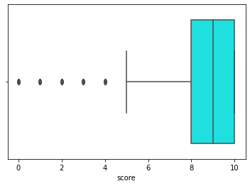

```
Boxplot of score
Q1 is :  8.0
Q2 is :  9.0
Q3 is :  10.0
IQR is: 2.0
Lower Whisker, Upper Whisker :  5.0 , 13.0
number of outliers are: 147884
```

```python
# 9. Check for outliers and impute them as required.
# only score is the column which is numeric so we check it for outliers.
#Checking for outliers in the sample of 1000000
sns.boxplot(x= d_df['score'], color='cyan')
plt.show()
print('Boxplot of score')
#calculating the outiers in attribute
Q1 = d_df['score'].quantile(0.25)
Q2 = d_df['score'].quantile(0.50)
Q3 = d_df['score'].quantile(0.75)
IQR = Q3 - Q1
L_W = (Q1 - 1.5 *IQR)
U_W = (Q3 + 1.5 *IQR)
print('Q1 is : ',Q1)
print('Q2 is : ',Q2)
print('Q3 is : ',Q3)
print('IQR is:',IQR)
print('Lower Whisker, Upper Whisker : ',L_W,',',U_W)
bools = (d_df['score'] < (Q1 - 1.5 *IQR)) |(d_df['score'] > (Q3 + 1.5 * IQR))
print('number of outliers are:',bools.sum())   #calculating the number of outliers
```

There are 147884 outliers in the column score

```python
Q1 = d_df['score'].quantile(0.25)
Q3 = d_df['score'].quantile(0.75)
IQR = Q3 - Q1
d_df = d_df[(d_df['score'] > (Q1 - 1.5 *IQR)) & (d_df['score'] < (Q3 + 1.5 *IQR))]
bools = (d_df['score'] < (Q1 - 1.5 *IQR)) |(d_df['score'] > (Q3 + 1.5 * IQR))
print('number of outliers are:',bools.sum())   #calculating the number of outliers
d_df.shape
```

```
number of outliers are: 0
```

```
(848829, 3)
```

```python
cross_validate(algo,data_U, measures=['RMSE'], cv=3, verbose=False)
```

```
Estimating biases using als...
Computing the pearson_baseline similarity matrix...
Done computing similarity matrix.
Estimating biases using als...
Computing the pearson_baseline similarity matrix...
Done computing similarity matrix.
Estimating biases using als...
Computing the pearson_baseline similarity matrix...
Done computing similarity matrix.
```

```
{'test_rmse': array([2.56157939, 2.60198462, 2.67417545]),
 'fit_time': (0.7393050193786621, 0.6737151145935059, 0.7524571418762207),
 'test_time': (0.054161787033081055, 0.04685044288635254, 0.03145146369934082)}
```

In what business scenario you should use CF based Recommendation Systems ?

Popularity based recommendation system relies on the popularity,trends and frequency counts of which items were most purchased.It is used buy the travel companies selling holiday packages in a season, by Google News and other news websites to show Top Stories with images.

What other possible methods can you think of which can further improve the recommendation for different users ?

Collaborative Filtering is used to building intelligent recommender systems that can learn to give better recommendations as more information about users is collected. It isa personalised recommender system , recommendations are made based on the past behaviour of the user. Most websites like Amazon, YouTube, and Netflix use collaborative filtering as a part of their sophisticated recommendation system.